# Migration Flows to Europe

#### Merge with Conflict Variables: Fatalities in Battles, Riots, and Violence against Civilians

The ACLED Project (Armed Conflict Location and Event Data) provides various measures of armed conflict, and the datasets on battles, riots and conflict against civilians will be imported to our analysis to measure the effect of conflict on the migration flows. The datasets are based on incidents or events. As a result there are multiple observations for countries, and we will calculate the total number of casualties in each country.

Since ACLED datasets include numeric iso3 codes, this project will use UN country codes datasets which include numeric iso3 codes.

As shown below with a total casualty of 13,414 Ukraine tops the list of fatalities in battles, becuase of Russian invasion. Myanmar comes the second, becuase of recent coup d'etat. And the countries with civil war follows these two countries. Similar tables are presented below for casualties in riots and violence against civilians.

If a country has a *NA* value for any of these conflict variables, this means that that country didnot have any casualties because of battles, riots, and violence. Hence we can simply fill the *NA* values with *0*.

The literature shows that the battles are much more important determinant of migration outflows than riots and violence towards civilians. To take this into consideration a new *casualties* variable will be created by weighting the existing three variables (battle fatalities 70%, and riot and vilence fatalities 15% each).

```python
# Numeric iso3 codes
immigration = immigration.merge(country_codes3_[['Iso3', 'Code']], how='left', left_on='Sending_iso3', right_on='Iso3')
immigration = immigration.drop(columns=['Iso3'])
immigration.rename(columns={'Code': 'Sending_iso3_num'}, inplace=True)
immigration
```

|  | Sending_Country | Flow | Sending_iso2 | Sending_iso3 | Sending_gdppc | Sending_mpm | Sending_incomegroup | Sending_iso3_num |
| --- | --- | --- | --- | --- | --- | --- | --- | --- |
| 0 | Afghanistan | 53037 | AF | AFG | 372.000000 | 68.499527 | Low Income | 4.0 |
| 1 | Albania | 131294 | AL | ALB | 15491.961000 | 0.293161 | High Income | 8.0 |
| 2 | Algeria | 58852 | DZ | DZA | 11198.233480 | 12.653047 | Upper-middle Income | 12.0 |
| 3 | Angola | 828 | AO | AGO | 5906.115677 | 47.203606 | Upper-middle Income | 24.0 |
| 4 | Antigua and Barbuda | 42 | AG | ATG | 22321.870020 | 2.721764 | High Income | 28.0 |
| ... | ... | ... | ... | ... | ... | ... | ... | ... |
| 162 | Viet Nam | 22106 | VN | VNM | 11396.531300 | 1.166175 | Upper-middle Income | 704.0 |
| 163 | Western Sahara | 0 | EH | ESH | 2500.000000 | 46.103936 | Lower-middle Income | 732.0 |
| 164 | Yemen | 8918 | YE | YEM | 1017.000000 | 35.411829 | Low Income | 887.0 |
| 165 | Zambia | 698 | ZM | ZMB | 3365.873780 | 66.403395 | Lower-middle Income | 894.0 |
| 166 | Zimbabwe | 1610 | ZW | ZWE | 2207.957033 | 42.397930 | Lower-middle Income | 716.0 |

167 rows × 8 columns

```python
# Countries with the most fatalities in battles.
battle1 = battle.groupby('country').agg({
    'fatalities': 'sum',
    'iso': 'first'
}).reset_index()

battle1.sort_values(by='fatalities', ascending=False)[:10]
```

|  | country | fatalities | iso |
| --- | --- | --- | --- |
| 95 | Ukraine | 13414 | 804 |
| 65 | Myanmar | 12901 | 104 |
| 69 | Nigeria | 5274 | 566 |
| 81 | Somalia | 4498 | 706 |
| 33 | Ethiopia | 3618 | 231 |
| 98 | Yemen | 3576 | 887 |
| 13 | Brazil | 3008 | 76 |
| 26 | Democratic Republic of Congo | 2919 | 180 |
| 86 | Syria | 2599 | 760 |
| 0 | Afghanistan | 2424 | 4 |

```python
# Merge with battle1 df
immigration = immigration.merge(battle1, how='left', left_on='Sending_iso3_num', right_on='iso')
immigration = immigration.drop(columns=['country', 'iso'])
immigration = immigration.rename(columns={'fatalities': 'battle_fatalities'})
immigration
```

|  | Sending_Country | Flow | Sending_iso2 | Sending_iso3 | Sending_gdppc | Sending_mpm | Sending_incomegroup | Sending_iso3_num | battle_fatalities |
| --- | --- | --- | --- | --- | --- | --- | --- | --- | --- |
| 0 | Afghanistan | 53037 | AF | AFG | 372.000000 | 68.499527 | Low Income | 4.0 | 2424.0 |
| 1 | Albania | 131294 | AL | ALB | 15491.961000 | 0.293161 | High Income | 8.0 | NaN |
| 2 | Algeria | 58852 | DZ | DZA | 11198.233480 | 12.653047 | Upper-middle Income | 12.0 | 19.0 |
| 3 | Angola | 828 | AO | AGO | 5906.115677 | 47.203606 | Upper-middle Income | 24.0 | 48.0 |
| 4 | Antigua and Barbuda | 42 | AG | ATG | 22321.870020 | 2.721764 | High Income | 28.0 | NaN |
| ... | ... | ... | ... | ... | ... | ... | ... | ... | ... |
| 162 | Viet Nam | 22106 | VN | VNM | 11396.531300 | 1.166175 | Upper-middle Income | 704.0 | NaN |
| 163 | Western Sahara | 0 | EH | ESH | 2500.000000 | 46.103936 | Lower-middle Income | 732.0 | NaN |
| 164 | Yemen | 8918 | YE | YEM | 1017.000000 | 35.411829 | Low Income | 887.0 | 3576.0 |
| 165 | Zambia | 698 | ZM | ZMB | 3365.873780 | 66.403395 | Lower-middle Income | 894.0 | NaN |
| 166 | Zimbabwe | 1610 | ZW | ZWE | 2207.957033 | 42.397930 | Lower-middle Income | 716.0 | 0.0 |

167 rows × 9 columns

```python
# Merge riot casualties
riot1 = riot.groupby('country').agg({'fatalities': 'sum','iso': 'first'}).reset_index()
print(riot1.sort_values(by='fatalities', ascending=False)[:10])

immigration = immigration.merge(riot1, how='left', left_on='Sending_iso3_num', right_on='iso')
immigration = immigration.drop(columns=['country', 'iso'])
immigration = immigration.rename(columns={'fatalities': 'riot_fatalities'})
immigration
```

```
                          country  fatalities  iso
65                           Iran         430  364
36   Democratic Republic of Congo         244  180
63                          India         214  356
75                          Kenya         211  404
106                       Nigeria         208  566
74                     Kazakhstan         185  398
136                  South Africa         169  710
10                     Bangladesh         151   50
64                      Indonesia         147  360
110                      Pakistan         142  586
```

|  | Sending_Country | Flow | Sending_iso2 | Sending_iso3 | Sending_gdppc | Sending_mpm | Sending_incomegroup | Sending_iso3_num | battle_fatalities | riot_fatalities |
| --- | --- | --- | --- | --- | --- | --- | --- | --- | --- | --- |
| 0 | Afghanistan | 53037 | AF | AFG | 372.000000 | 68.499527 | Low Income | 4.0 | 2424.0 | 24.0 |
| 1 | Albania | 131294 | AL | ALB | 15491.961000 | 0.293161 | High Income | 8.0 | NaN | 0.0 |
| 2 | Algeria | 58852 | DZ | DZA | 11198.233480 | 12.653047 | Upper-middle Income | 12.0 | 19.0 | 0.0 |
| 3 | Angola | 828 | AO | AGO | 5906.115677 | 47.203606 | Upper-middle Income | 24.0 | 48.0 | 34.0 |
| 4 | Antigua and Barbuda | 42 | AG | ATG | 22321.870020 | 2.721764 | High Income | 28.0 | NaN | NaN |
| ... | ... | ... | ... | ... | ... | ... | ... | ... | ... | ... |
| 162 | Viet Nam | 22106 | VN | VNM | 11396.531300 | 1.166175 | Upper-middle Income | 704.0 | NaN | NaN |
| 163 | Western Sahara | 0 | EH | ESH | 2500.000000 | 46.103936 | Lower-middle Income | 732.0 | NaN | NaN |
| 164 | Yemen | 8918 | YE | YEM | 1017.000000 | 35.411829 | Low Income | 887.0 | 3576.0 | 0.0 |
| 165 | Zambia | 698 | ZM | ZMB | 3365.873780 | 66.403395 | Lower-middle Income | 894.0 | NaN | 8.0 |
| 166 | Zimbabwe | 1610 | ZW | ZWE | 2207.957033 | 42.397930 | Lower-middle Income | 716.0 | 0.0 | 27.0 |

167 rows × 10 columns

```python
# Merge Violence casualties
violence1 = violence.groupby('country').agg({'fatalities': 'sum','iso': 'first'}).reset_index()
print(violence1.sort_values(by='fatalities', ascending=False)[:10])

immigration = immigration.merge(violence1, how='left', left_on='Sending_iso3_num', right_on='iso')
immigration = immigration.drop(columns=['country', 'iso'])
immigration = immigration.rename(columns={'fatalities': 'violence_fatalities'})
immigration
```

```
                          country  fatalities  iso
80                         Mexico        6561  484
16                         Brazil        4034   76
90                        Nigeria        3701  566
31   Democratic Republic of Congo        3046  180
39                       Ethiopia        2614  231
84                        Myanmar        2188  104
76                           Mali        2151  466
26                       Colombia        1680  170
134                       Ukraine        1348  804
17                   Burkina Faso        1177  854
```

|  | Sending_Country | Flow | Sending_iso2 | Sending_iso3 | Sending_gdppc | Sending_mpm | Sending_incomegroup | Sending_iso3_num | battle_fatalities | riot_fatalities | violence_fatalities |
| --- | --- | --- | --- | --- | --- | --- | --- | --- | --- | --- | --- |
| 0 | Afghanistan | 53037 | AF | AFG | 372.000000 | 68.499527 | Low Income | 4.0 | 2424.0 | 24.0 | 741.0 |
| 1 | Albania | 131294 | AL | ALB | 15491.961000 | 0.293161 | High Income | 8.0 | NaN | 0.0 | 0.0 |
| 2 | Algeria | 58852 | DZ | DZA | 11198.233480 | 12.653047 | Upper-middle Income | 12.0 | 19.0 | 0.0 | 8.0 |
| 3 | Angola | 828 | AO | AGO | 5906.115677 | 47.203606 | Upper-middle Income | 24.0 | 48.0 | 34.0 | 22.0 |
| 4 | Antigua and Barbuda | 42 | AG | ATG | 22321.870020 | 2.721764 | High Income | 28.0 | NaN | NaN | NaN |
| ... | ... | ... | ... | ... | ... | ... | ... | ... | ... | ... | ... |
| 162 | Viet Nam | 22106 | VN | VNM | 11396.531300 | 1.166175 | Upper-middle Income | 704.0 | NaN | NaN | NaN |
| 163 | Western Sahara | 0 | EH | ESH | 2500.000000 | 46.103936 | Lower-middle Income | 732.0 | NaN | NaN | NaN |
| 164 | Yemen | 8918 | YE | YEM | 1017.000000 | 35.411829 | Low Income | 887.0 | 3576.0 | 0.0 | 294.0 |
| 165 | Zambia | 698 | ZM | ZMB | 3365.873780 | 66.403395 | Lower-middle Income | 894.0 | NaN | 8.0 | 3.0 |
| 166 | Zimbabwe | 1610 | ZW | ZWE | 2207.957033 | 42.397930 | Lower-middle Income | 716.0 | 0.0 | 27.0 | 6.0 |

167 rows × 11 columns

```python
# Fill all NAs with 0
immigration[['battle_fatalities', 'riot_fatalities', 'violence_fatalities']] = immigration[['battle_fatalities', 'riot_fatalities', 'violence_fatalities']].fillna(0)
immigration
```

|  | Sending_Country | Flow | Sending_iso2 | Sending_iso3 | Sending_gdppc | Sending_mpm | Sending_incomegroup | Sending_iso3_num | battle_fatalities | riot_fatalities | violence_fatalities |
| --- | --- | --- | --- | --- | --- | --- | --- | --- | --- | --- | --- |
| 0 | Afghanistan | 53037 | AF | AFG | 372.000000 | 68.499527 | Low Income | 4.0 | 2424.0 | 24.0 | 741.0 |
| 1 | Albania | 131294 | AL | ALB | 15491.961000 | 0.293161 | High Income | 8.0 | 0.0 | 0.0 | 0.0 |
| 2 | Algeria | 58852 | DZ | DZA | 11198.233480 | 12.653047 | Upper-middle Income | 12.0 | 19.0 | 0.0 | 8.0 |
| 3 | Angola | 828 | AO | AGO | 5906.115677 | 47.203606 | Upper-middle Income | 24.0 | 48.0 | 34.0 | 22.0 |
| 4 | Antigua and Barbuda | 42 | AG | ATG | 22321.870020 | 2.721764 | High Income | 28.0 | 0.0 | 0.0 | 0.0 |
| ... | ... | ... | ... | ... | ... | ... | ... | ... | ... | ... | ... |
| 162 | Viet Nam | 22106 | VN | VNM | 11396.531300 | 1.166175 | Upper-middle Income | 704.0 | 0.0 | 0.0 | 0.0 |
| 163 | Western Sahara | 0 | EH | ESH | 2500.000000 | 46.103936 | Lower-middle Income | 732.0 | 0.0 | 0.0 | 0.0 |
| 164 | Yemen | 8918 | YE | YEM | 1017.000000 | 35.411829 | Low Income | 887.0 | 3576.0 | 0.0 | 294.0 |
| 165 | Zambia | 698 | ZM | ZMB | 3365.873780 | 66.403395 | Lower-middle Income | 894.0 | 0.0 | 8.0 | 3.0 |
| 166 | Zimbabwe | 1610 | ZW | ZWE | 2207.957033 | 42.397930 | Lower-middle Income | 716.0 | 0.0 | 27.0 | 6.0 |

167 rows × 11 columns

```python
# Create conflict_casualties
immigration['Sending_conflict_casualties'] = (immigration['battle_fatalities'] * 0.70) + (immigration['riot_fatalities']*0.15) + (immigration['violence_fatalities']*0.15)
immigration = immigration.drop(columns=['battle_fatalities', 'riot_fatalities', 'violence_fatalities'])
immigration
```

|  | Sending_Country | Flow | Sending_iso2 | Sending_iso3 | Sending_gdppc | Sending_mpm | Sending_incomegroup | Sending_iso3_num | Sending_conflict_casualties |
| --- | --- | --- | --- | --- | --- | --- | --- | --- | --- |
| 0 | Afghanistan | 53037 | AF | AFG | 372.000000 | 68.499527 | Low Income | 4.0 | 1811.55 |
| 1 | Albania | 131294 | AL | ALB | 15491.961000 | 0.293161 | High Income | 8.0 | 0.00 |
| 2 | Algeria | 58852 | DZ | DZA | 11198.233480 | 12.653047 | Upper-middle Income | 12.0 | 14.50 |
| 3 | Angola | 828 | AO | AGO | 5906.115677 | 47.203606 | Upper-middle Income | 24.0 | 42.00 |
| 4 | Antigua and Barbuda | 42 | AG | ATG | 22321.870020 | 2.721764 | High Income | 28.0 | 0.00 |
| ... | ... | ... | ... | ... | ... | ... | ... | ... | ... |
| 162 | Viet Nam | 22106 | VN | VNM | 11396.531300 | 1.166175 | Upper-middle Income | 704.0 | 0.00 |
| 163 | Western Sahara | 0 | EH | ESH | 2500.000000 | 46.103936 | Lower-middle Income | 732.0 | 0.00 |
| 164 | Yemen | 8918 | YE | YEM | 1017.000000 | 35.411829 | Low Income | 887.0 | 2547.30 |
| 165 | Zambia | 698 | ZM | ZMB | 3365.873780 | 66.403395 | Lower-middle Income | 894.0 | 1.65 |
| 166 | Zimbabwe | 1610 | ZW | ZWE | 2207.957033 | 42.397930 | Lower-middle Income | 716.0 | 4.95 |

167 rows × 9 columns

#### Merge with Political Indicators: WB Governance Indicators

WB Governance Indicators dataset simply has measures of "Political Stability and Absence of Violence", "Voice and Accountability", "Control of Corruption", "Regulatory Quality", "Government Effectiveness", and "Rule of Law".

This dataset mainly has one column for country, and "Series Name" column for (1) estimates and (2) percentiles of above listed measures. This means that all 12 variables (6 estimates and 6 percentiles) are under "Series Name", and there are 12 total observation for each country. To tidy data, *pivot_table* function is used to spread these 12 variables to columns.

This dataset includes both estimates and percentile rankings. For the sake of simplicity, one single governance quality variable will be calculated only using the estimates variables.

The estimates range between -3.5 and +3.5. So as to make all of the estimates higher than **0**, each estimate will be added **3.5** points. After this, all of the 6 estimates will be summed into a new *Sending_govern* variable as 1 single governance indicator of sending countries.

Again, the missing governance score variable will be filled with the average of the income group

```python
# What kind of measures does WB Governance Indicators dataset have?
display(govern.head())
govern["Series Name"].unique()
```

|  | Country Name | Country Code | Series Name | Series Code | 2022 [YR2022] |
| --- | --- | --- | --- | --- | --- |
| 0 | Afghanistan | AFG | Political Stability and Absence of Violence/Te... | PV.EST | -2.550801754 |
| 1 | Afghanistan | AFG | Voice and Accountability: Estimate | VA.EST | -1.751587272 |
| 2 | Korea, Dem. People's Rep. | PRK | Voice and Accountability: Percentile Rank | VA.PER.RNK | 0 |
| 3 | Afghanistan | AFG | Control of Corruption: Estimate | CC.EST | -1.183776498 |
| 4 | Korea, Dem. People's Rep. | PRK | Regulatory Quality: Percentile Rank | RQ.PER.RNK | 0 |

```
array(['Political Stability and Absence of Violence/Terrorism: Estimate',
       'Voice and Accountability: Estimate',
       'Voice and Accountability: Percentile Rank',
       'Control of Corruption: Estimate',
       'Regulatory Quality: Percentile Rank',
       'Government Effectiveness: Estimate',
       'Rule of Law: Percentile Rank',
       'Control of Corruption: Percentile Rank',
       'Regulatory Quality: Estimate',
       'Government Effectiveness: Percentile Rank',
       'Rule of Law: Estimate',
       'Political Stability and Absence of Violence/Terrorism: Percentile Rank',
       nan], dtype=object)
```

```python
# Tidy data using pivot_table function
govern['2022 [YR2022]'] = pd.to_numeric(govern['2022 [YR2022]'], errors='coerce')
govern_p = govern.pivot_table(index='Country Name', columns='Series Name', values='2022 [YR2022]').reset_index()
govern_p.head()
```

| Series Name | Country Name | Control of Corruption: Estimate | Control of Corruption: Percentile Rank | Government Effectiveness: Estimate | Government Effectiveness: Percentile Rank | Political Stability and Absence of Violence/Terrorism: Estimate | Political Stability and Absence of Violence/Terrorism: Percentile Rank | Regulatory Quality: Estimate | Regulatory Quality: Percentile Rank | Rule of Law: Estimate | Rule of Law: Percentile Rank | Voice and Accountability: Estimate | Voice and Accountability: Percentile Rank |
| --- | --- | --- | --- | --- | --- | --- | --- | --- | --- | --- | --- | --- | --- |
| 0 | Afghanistan | -1.183776 | 12.264151 | -1.879552 | 1.886792 | -2.550802 | 0.471698 | -1.271806 | 8.962264 | -1.658442 | 5.188679 | -1.751587 | 2.415459 |
| 1 | Albania | -0.407876 | 38.679245 | 0.065063 | 56.603775 | 0.114945 | 50.471699 | 0.159354 | 57.547169 | -0.165779 | 47.169811 | 0.139466 | 52.173912 |
| 2 | Algeria | -0.637930 | 28.301888 | -0.513090 | 32.547169 | -0.741772 | 19.339623 | -1.063573 | 14.150944 | -0.832473 | 22.641510 | -1.003874 | 21.739130 |
| 3 | American Samoa | 1.270204 | 88.679245 | 0.667918 | 74.528305 | 1.128859 | 91.037735 | 0.545900 | 70.754715 | 1.221118 | 86.320755 | 0.957648 | 77.294685 |
| 4 | Andorra | 1.270204 | 88.679245 | 1.495305 | 92.452827 | 1.587736 | 98.584908 | 1.398334 | 90.094337 | 1.485450 | 90.566040 | 1.102833 | 85.507248 |

```python
# Add 3.5 to all estimates so that estimates will be above 0.
govern_p[['Control of Corruption: Estimate', 'Government Effectiveness: Estimate', 'Political Stability and Absence of Violence/Terrorism: Estimate', 'Regulatory Quality: Estimate', 'Rule of Law: Estimate',	'Voice and Accountability: Estimate']] += 3.5
```

```python
# Calculate one governance variable by simply summing up all of the estimate variables
govern_p['Sending_govern'] = (govern_p['Control of Corruption: Estimate']) + (govern_p['Government Effectiveness: Estimate']) + (govern_p['Political Stability and Absence of Violence/Terrorism: Estimate']) + (govern_p['Regulatory Quality: Estimate']) + (govern_p['Rule of Law: Estimate']) + (govern_p['Voice and Accountability: Estimate'])

govern_p.head()
```

| Series Name | Country Name | Control of Corruption: Estimate | Control of Corruption: Percentile Rank | Government Effectiveness: Estimate | Government Effectiveness: Percentile Rank | Political Stability and Absence of Violence/Terrorism: Estimate | Political Stability and Absence of Violence/Terrorism: Percentile Rank | Regulatory Quality: Estimate | Regulatory Quality: Percentile Rank | Rule of Law: Estimate | Rule of Law: Percentile Rank | Voice and Accountability: Estimate | Voice and Accountability: Percentile Rank | Sending_govern |
| --- | --- | --- | --- | --- | --- | --- | --- | --- | --- | --- | --- | --- | --- | --- |
| 0 | Afghanistan | 2.316224 | 12.264151 | 1.620448 | 1.886792 | 0.949198 | 0.471698 | 2.228194 | 8.962264 | 1.841558 | 5.188679 | 1.748413 | 2.415459 | 10.704034 |
| 1 | Albania | 3.092124 | 38.679245 | 3.565063 | 56.603775 | 3.614945 | 50.471699 | 3.659354 | 57.547169 | 3.334221 | 47.169811 | 3.639466 | 52.173912 | 20.905173 |
| 2 | Algeria | 2.862070 | 28.301888 | 2.986910 | 32.547169 | 2.758228 | 19.339623 | 2.436427 | 14.150944 | 2.667527 | 22.641510 | 2.496126 | 21.739130 | 16.207288 |
| 3 | American Samoa | 4.770204 | 88.679245 | 4.167918 | 74.528305 | 4.628859 | 91.037735 | 4.045900 | 70.754715 | 4.721118 | 86.320755 | 4.457648 | 77.294685 | 26.791646 |
| 4 | Andorra | 4.770204 | 88.679245 | 4.995305 | 92.452827 | 5.087736 | 98.584908 | 4.898334 | 90.094337 | 4.985450 | 90.566040 | 4.602833 | 85.507248 | 29.339862 |

```python
# Merge govern_p with Immigration Dataset and bring governance indicator.
immigration = pd.merge(immigration, govern_p[['Country Name', 'Sending_govern']], left_on='Sending_Country', right_on='Country Name', how='left')
immigration.drop(columns=['Country Name'], inplace=True)

immigration.head(3)
```

|  | Sending_Country | Flow | Sending_iso2 | Sending_iso3 | Sending_gdppc | Sending_mpm | Sending_incomegroup | Sending_iso3_num | Sending_conflict_casualties | Sending_govern |
| --- | --- | --- | --- | --- | --- | --- | --- | --- | --- | --- |
| 0 | Afghanistan | 53037 | AF | AFG | 372.00000 | 68.499527 | Low Income | 4.0 | 1811.55 | 10.704034 |
| 1 | Albania | 131294 | AL | ALB | 15491.96100 | 0.293161 | High Income | 8.0 | 0.00 | 20.905173 |
| 2 | Algeria | 58852 | DZ | DZA | 11198.23348 | 12.653047 | Upper-middle Income | 12.0 | 14.50 | 16.207288 |

```python
# Fill missing Sending_mpm values

#Calculate average mpm for each income group
govern_average = immigration.groupby('Sending_incomegroup')['Sending_govern'].transform('mean')

# Fill missing Sending_mpm values with the average values based on Income_group
immigration['Sending_govern'].fillna(govern_average, inplace=True)

immigration.head()
```

|  | Sending_Country | Flow | Sending_iso2 | Sending_iso3 | Sending_gdppc | Sending_mpm | Sending_incomegroup | Sending_iso3_num | Sending_conflict_casualties | Sending_govern |
| --- | --- | --- | --- | --- | --- | --- | --- | --- | --- | --- |
| 0 | Afghanistan | 53037 | AF | AFG | 372.000000 | 68.499527 | Low Income | 4.0 | 1811.55 | 10.704034 |
| 1 | Albania | 131294 | AL | ALB | 15491.961000 | 0.293161 | High Income | 8.0 | 0.00 | 20.905173 |
| 2 | Algeria | 58852 | DZ | DZA | 11198.233480 | 12.653047 | Upper-middle Income | 12.0 | 14.50 | 16.207288 |
| 3 | Angola | 828 | AO | AGO | 5906.115677 | 47.203606 | Upper-middle Income | 24.0 | 42.00 | 16.285654 |
| 4 | Antigua and Barbuda | 42 | AG | ATG | 22321.870020 | 2.721764 | High Income | 28.0 | 0.00 | 23.496961 |

#### Merge with Climate Indicator: German Watch Climate Risk Index

Even though German Watch's Climate Risk Index is the most comprehensive climate risk dataset, there are still many countries with a missing climate risk value. Even the social, political, and economic factors are influential in explaining climate risk, such as a low state capacity would increase the climate risk a country face, still climate risks are far less effected by these factors. Netherlands, as a highly developed country, has a climate risk.

Before of this reason, the missing values will simply be filled with the average score so as not to miss a big chunk of observations.

```python
# Merge govern_p with Immigration Dataset and bring governance indicator.
immigration = pd.merge(immigration, climate[['Country', 'CRI\rscore']], left_on='Sending_Country', right_on='Country', how='left')
immigration.drop(columns=['Country'], inplace=True)

# Rename 'CRI/rscore' Column with 'Sending_cri'
immigration.rename(columns={'CRI\rscore': 'Sending_cri'}, inplace=True)

immigration
```

|  | Sending_Country | Flow | Sending_iso2 | Sending_iso3 | Sending_gdppc | Sending_mpm | Sending_incomegroup | Sending_iso3_num | Sending_conflict_casualties | Sending_govern | Sending_cri |
| --- | --- | --- | --- | --- | --- | --- | --- | --- | --- | --- | --- |
| 0 | Afghanistan | 53037 | AF | AFG | 372.000000 | 68.499527 | Low Income | 4.0 | 1811.55 | 10.704034 | NaN |
| 1 | Albania | 131294 | AL | ALB | 15491.961000 | 0.293161 | High Income | 8.0 | 0.00 | 20.905173 | 108.00 |
| 2 | Algeria | 58852 | DZ | DZA | 11198.233480 | 12.653047 | Upper-middle Income | 12.0 | 14.50 | 16.207288 | 93.83 |
| 3 | Angola | 828 | AO | AGO | 5906.115677 | 47.203606 | Upper-middle Income | 24.0 | 42.00 | 16.285654 | 76.00 |
| 4 | Antigua and Barbuda | 42 | AG | ATG | 22321.870020 | 2.721764 | High Income | 28.0 | 0.00 | 23.496961 | 125.00 |
| ... | ... | ... | ... | ... | ... | ... | ... | ... | ... | ... | ... |
| 162 | Viet Nam | 22106 | VN | VNM | 11396.531300 | 1.166175 | Upper-middle Income | 704.0 | 0.00 | 18.866787 | NaN |
| 163 | Western Sahara | 0 | EH | ESH | 2500.000000 | 46.103936 | Lower-middle Income | 732.0 | 0.00 | 16.658763 | NaN |
| 164 | Yemen | 8918 | YE | YEM | 1017.000000 | 35.411829 | Low Income | 887.0 | 2547.30 | 11.075789 | NaN |
| 165 | Zambia | 698 | ZM | ZMB | 3365.873780 | 66.403395 | Lower-middle Income | 894.0 | 1.65 | 18.777528 | 125.00 |
| 166 | Zimbabwe | 1610 | ZW | ZWE | 2207.957033 | 42.397930 | Lower-middle Income | 716.0 | 4.95 | 13.841291 | 114.50 |

167 rows × 11 columns

```python
# Missing values
missing_cri = immigration[immigration['Sending_cri'].isna()]

display(missing_cri['Sending_Country'].unique())

display(missing_cri.groupby('Sending_Country')['Flow'].sum().sort_values(ascending=False))

display(missing_cri['Flow'].sum())
```

```
array(['Afghanistan', 'Bahamas', 'Congo',
       'Congo, the Democratic Republic of the', 'Cuba',
       'Equatorial Guinea', 'Gambia', 'Iran', 'North Korea', 'Kyrgyzstan',
       "Lao People's Democratic Republic", 'Macedonia',
       'Micronesia, Federated States of', 'Moldova, Republic of', 'Nauru',
       'Non-Citizens', 'Palau', 'Palestine, State of',
       'Russian Federation', 'Saint Kitts and Nevis', 'Saint Lucia',
       'Saint Vincent and the Grenadines', 'Sao Tome and Principe',
       'Somalia', 'Stateless', 'Swaziland', 'Syria', 'Taiwan',
       'Timor-Leste', 'Turkmenistan', 'Unkown', 'Viet Nam',
       'Western Sahara', 'Yemen'], dtype=object)
```

```
Sending_Country
Russian Federation                       196630
Syria                                    138876
Cuba                                      82456
Afghanistan                               53037
Iran                                      43182
Moldova, Republic of                      40375
Unkown                                    35760
Macedonia                                 28024
Gambia                                    22640
Viet Nam                                  22106
Somalia                                   14831
Stateless                                 11142
Equatorial Guinea                         10398
Kyrgyzstan                                 9474
Yemen                                      8918
Congo, the Democratic Republic of the      6594
Non-Citizens                               4090
Taiwan                                     3608
Palestine, State of                        2424
Turkmenistan                               1849
Congo                                      1426
Lao People's Democratic Republic            328
Saint Kitts and Nevis                       108
North Korea                                  78
Sao Tome and Principe                        68
Saint Lucia                                  62
Swaziland                                    52
Timor-Leste                                  42
Bahamas                                      34
Saint Vincent and the Grenadines             30
Palau                                         4
Nauru                                         0
Western Sahara                                0
Micronesia, Federated States of               0
Name: Flow, dtype: int64
```

```
738646
```

```python
# Replace the missing values under Sending_cri column with the average of the column

# The average of the 'Sending_gdppc' column
average_cri = immigration['Sending_cri'].mean()

# Fill missing values in the 'Sending_gdppc' column with the calculated average
immigration['Sending_cri'].fillna(average_cri, inplace=True)
immigration
```

|  | Sending_Country | Flow | Sending_iso2 | Sending_iso3 | Sending_gdppc | Sending_mpm | Sending_incomegroup | Sending_iso3_num | Sending_conflict_casualties | Sending_govern | Sending_cri |
| --- | --- | --- | --- | --- | --- | --- | --- | --- | --- | --- | --- |
| 0 | Afghanistan | 53037 | AF | AFG | 372.000000 | 68.499527 | Low Income | 4.0 | 1811.55 | 10.704034 | 82.451203 |
| 1 | Albania | 131294 | AL | ALB | 15491.961000 | 0.293161 | High Income | 8.0 | 0.00 | 20.905173 | 108.000000 |
| 2 | Algeria | 58852 | DZ | DZA | 11198.233480 | 12.653047 | Upper-middle Income | 12.0 | 14.50 | 16.207288 | 93.830000 |
| 3 | Angola | 828 | AO | AGO | 5906.115677 | 47.203606 | Upper-middle Income | 24.0 | 42.00 | 16.285654 | 76.000000 |
| 4 | Antigua and Barbuda | 42 | AG | ATG | 22321.870020 | 2.721764 | High Income | 28.0 | 0.00 | 23.496961 | 125.000000 |
| ... | ... | ... | ... | ... | ... | ... | ... | ... | ... | ... | ... |
| 162 | Viet Nam | 22106 | VN | VNM | 11396.531300 | 1.166175 | Upper-middle Income | 704.0 | 0.00 | 18.866787 | 82.451203 |
| 163 | Western Sahara | 0 | EH | ESH | 2500.000000 | 46.103936 | Lower-middle Income | 732.0 | 0.00 | 16.658763 | 82.451203 |
| 164 | Yemen | 8918 | YE | YEM | 1017.000000 | 35.411829 | Low Income | 887.0 | 2547.30 | 11.075789 | 82.451203 |
| 165 | Zambia | 698 | ZM | ZMB | 3365.873780 | 66.403395 | Lower-middle Income | 894.0 | 1.65 | 18.777528 | 125.000000 |
| 166 | Zimbabwe | 1610 | ZW | ZWE | 2207.957033 | 42.397930 | Lower-middle Income | 716.0 | 4.95 | 13.841291 | 114.500000 |

167 rows × 11 columns

#### Population Indicator

The population of a country is a natural determinant of total flow of migrants. Therefore, this project will import population information from CIA.

Some countries have missing population information, however this is simply because of mismatch between the columns (such as "Syria" vs "Syrian Arab Republic"). We will manually fill these NaN values using the CIA population dataset.

For the Stateless, Unkown, and Recognized Non-Citizen observations, we will simply use the average population.

```python
# Merge population with Immigration Dataset and bring governance indicator.
#immigration = immigration.drop(columns=['Sending_pop', 'value'])
immigration = pd.merge(immigration, population[['name', 'value']], left_on='Sending_Country', right_on='name', how='left')
immigration.drop(columns=['name'], inplace=True)

immigration.head()
```

|  | Sending_Country | Flow | Sending_iso2 | Sending_iso3 | Sending_gdppc | Sending_mpm | Sending_incomegroup | Sending_iso3_num | Sending_conflict_casualties | Sending_govern | Sending_cri | value |
| --- | --- | --- | --- | --- | --- | --- | --- | --- | --- | --- | --- | --- |
| 0 | Afghanistan | 53037 | AF | AFG | 372.000000 | 68.499527 | Low Income | 4.0 | 1811.55 | 10.704034 | 82.451203 | 38,346,720 |
| 1 | Albania | 131294 | AL | ALB | 15491.961000 | 0.293161 | High Income | 8.0 | 0.00 | 20.905173 | 108.000000 | 3,095,344 |
| 2 | Algeria | 58852 | DZ | DZA | 11198.233480 | 12.653047 | Upper-middle Income | 12.0 | 14.50 | 16.207288 | 93.830000 | 44,178,884 |
| 3 | Angola | 828 | AO | AGO | 5906.115677 | 47.203606 | Upper-middle Income | 24.0 | 42.00 | 16.285654 | 76.000000 | 34,795,287 |
| 4 | Antigua and Barbuda | 42 | AG | ATG | 22321.870020 | 2.721764 | High Income | 28.0 | 0.00 | 23.496961 | 125.000000 | 100,335 |

```python
# Rename 'value' Column with 'Sending_pop'
immigration.rename(columns={'value': 'Sending_pop'}, inplace=True)
immigration.head()
```

|  | Sending_Country | Flow | Sending_iso2 | Sending_iso3 | Sending_gdppc | Sending_mpm | Sending_incomegroup | Sending_iso3_num | Sending_conflict_casualties | Sending_govern | Sending_cri | Sending_pop |
| --- | --- | --- | --- | --- | --- | --- | --- | --- | --- | --- | --- | --- |
| 0 | Afghanistan | 53037 | AF | AFG | 372.000000 | 68.499527 | Low Income | 4.0 | 1811.55 | 10.704034 | 82.451203 | 38,346,720 |
| 1 | Albania | 131294 | AL | ALB | 15491.961000 | 0.293161 | High Income | 8.0 | 0.00 | 20.905173 | 108.000000 | 3,095,344 |
| 2 | Algeria | 58852 | DZ | DZA | 11198.233480 | 12.653047 | Upper-middle Income | 12.0 | 14.50 | 16.207288 | 93.830000 | 44,178,884 |
| 3 | Angola | 828 | AO | AGO | 5906.115677 | 47.203606 | Upper-middle Income | 24.0 | 42.00 | 16.285654 | 76.000000 | 34,795,287 |
| 4 | Antigua and Barbuda | 42 | AG | ATG | 22321.870020 | 2.721764 | High Income | 28.0 | 0.00 | 23.496961 | 125.000000 | 100,335 |

```python
# 10 countries with missing population information. This is because of name mismatch.
print(immigration['Sending_pop'].isna().sum())
immigration[immigration['Sending_pop'].isna()]
```

```
10
```

|  | Sending_Country | Flow | Sending_iso2 | Sending_iso3 | Sending_gdppc | Sending_mpm | Sending_incomegroup | Sending_iso3_num | Sending_conflict_casualties | Sending_govern | Sending_cri | Sending_pop |
| --- | --- | --- | --- | --- | --- | --- | --- | --- | --- | --- | --- | --- |
| 17 | Bolivia | 36624 | BO | BOL | 8244.235658 | 4.539775 | Upper-middle Income | 68.0 | 2.20 | 16.553992 | 63.500000 | NaN |
| 38 | Côte d'Ivoire | 8292 | CI | CIV | 5537.369758 | 37.273455 | Upper-middle Income | 384.0 | 21.05 | 18.866787 | 89.500000 | NaN |
| 63 | Iran | 43182 | IR | IRN | 15461.079340 | 1.027940 | High Income | 364.0 | 136.15 | 22.317889 | 82.451203 | NaN |
| 72 | North Korea | 78 | KP | PRK | 1217.000000 | 46.103936 | Lower-middle Income | 408.0 | 5.10 | 16.658763 | 82.451203 | NaN |
| 81 | Macedonia | 28024 | MK | MKD | 17128.642860 | 3.205135 | High Income | 807.0 | 0.00 | 22.317889 | 82.451203 | NaN |
| 105 | Non-Citizens | 4090 | RNC | XXX | 15549.957897 | 2.721764 | High Income | NaN | 0.00 | 22.317889 | 82.451203 | NaN |
| 140 | Syria | 138876 | SY | SYR | 752.000000 | 68.499527 | Low Income | 760.0 | 1945.75 | 11.075789 | 82.451203 | NaN |
| 141 | Taiwan | 3608 | TW | TWN | 32716.000000 | 0.061490 | High Income | 158.0 | 0.00 | 22.317889 | 82.451203 | NaN |
| 143 | Tanzania | 1536 | TZ | TZA | 2623.861572 | 54.589677 | Lower-middle Income | 834.0 | 9.15 | 18.300585 | 69.830000 | NaN |
| 161 | Venezuela | 340468 | VE | VEN | 3420.000000 | 46.103936 | Lower-middle Income | 862.0 | 445.85 | 16.658763 | 104.170000 | NaN |

```python
# Fill the missing population information manually
missing_pop = {
    'Bolivia': 12311974,
    "Côte d'Ivoire": 29981758,
    'Iran': 88386937,
    'North Korea': 26298666,
    'Macedonia': 2135622,
    'Syria': 23865423,
    'Taiwan': 23595274,
    'Tanzania': 67462121,
    'Venezuela': 31250306
}

# Fill missing GDP per capita values based on Sending_Country
immigration['Sending_pop'] = immigration.apply(
    lambda row: missing_pop[row['Sending_Country']] if pd.isna(row['Sending_pop']) and row['Sending_Country'] in missing_pop else row['Sending_pop'],
    axis=1
)

# Check the remaining missing countries
print(immigration[immigration['Sending_pop'].isna()])
```

```
    Sending_Country  Flow Sending_iso2 Sending_iso3  Sending_gdppc  \
105    Non-Citizens  4090          RNC          XXX   15549.957897

     Sending_mpm Sending_incomegroup  Sending_iso3_num  \
105     2.721764         High Income               NaN

     Sending_conflict_casualties  Sending_govern  Sending_cri Sending_pop
105                          0.0       22.317889    82.451203         NaN
```

```python
# Calculate the average of Sending_pop
immigration['Sending_pop'] = pd.to_numeric(immigration['Sending_pop'], errors='coerce')
average_pop = immigration['Sending_pop'].mean()

# Fill missing Sending_pop values with the average
immigration['Sending_pop'] = immigration['Sending_pop'].fillna(average_pop)


# Missing values
print(immigration['Sending_pop'].isna().sum())
```

```
0
```

## Statistical Modelling

As indicated above, this research will use a multiple linear regression model to predict the migration flows to Europe, based on various economic, political, conflict, climate-related, and population variables.

First of all, to see the association between the outcome variable and the explanatory variables, and also to see how each variable is correlated with each other we will present individual scatterplots and also a correlation heatmap.

As it can be seen from the scatterplot, the conflict casualties has the steepest regression line with the a p-value lower than the threshold value.

At the correlation matrix heatmap, conflict fatalities exhibit a positive correlation with the migration flow compared to other variables.

Moreover, in line with conventional wisdom, GDP/PC demonstrates a negative correlation with the poverty measure and a positive correlation with governance indicators.

Consequently, it would be reasonable to hypothesize that an increase in fatalities resulting from civil and armed conflict would lead to an increase in migration outflows.

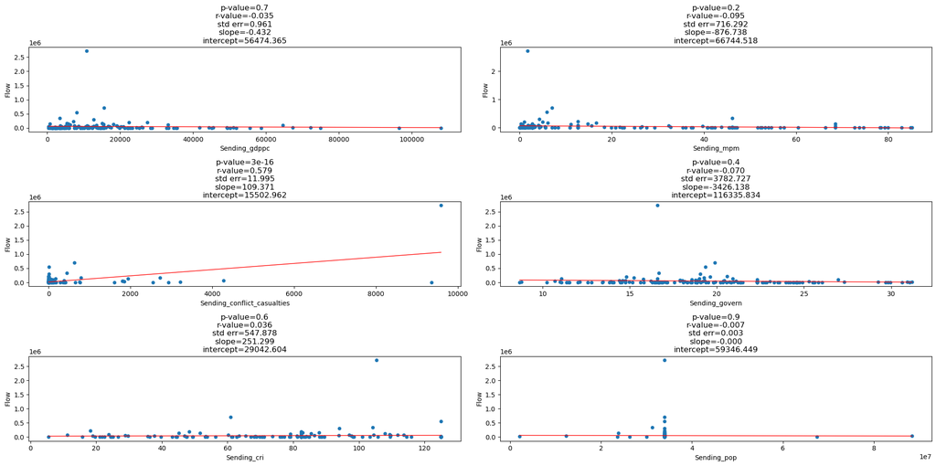

```python
# Individual scatter plots
import matplotlib.pyplot as plt
import numpy as np
import scipy.stats as stats

observations = ['Sending_gdppc', 'Sending_mpm', 'Sending_conflict_casualties', 'Sending_govern', 'Sending_cri', 'Sending_pop']

def regress_with_stats(immigration, observations):
    fig, ax = plt.subplots(3, 2, figsize=(20, 10), sharex=False)
    ax = ax.ravel()

    for i, o in enumerate(observations):
        slope, intercept, r_value, p_value, std_err = stats.linregress(
            immigration[o],
            immigration['Flow']
        )
        # A title with statistics
        diag_str = (
            f"p-value={p_value:.1g}\n"
            f"r-value={r_value:.3f}\n"
            f"std err={std_err:.3f}\n"
            f"slope={slope:.3f}\n"
            f"intercept={intercept:.3f}"
        )

        # Scatter plot with regression line
        immigration.plot.scatter(x=o, y='Flow', title=diag_str, ax=ax[i])
        pts = np.linspace(immigration[o].min(), immigration[o].max(), 500)
        line = slope * pts + intercept
        ax[i].plot(pts, line, lw=1, color='red')

    for i in range(len(observations), len(ax)):
        fig.delaxes(ax[i])

    plt.tight_layout()
    plt.show()

regress_with_stats(immigration, observations)
```

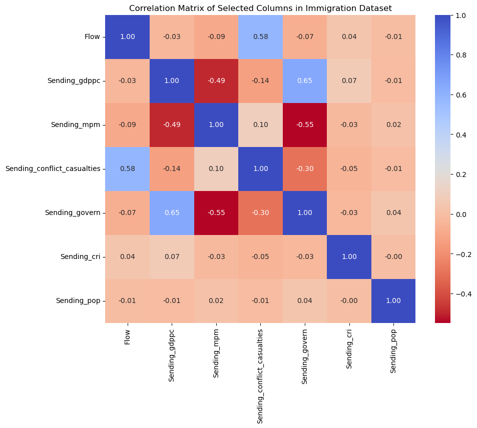

```python
import seaborn as sns
# Coerce variables into numeric values
immigration['Flow'] = pd.to_numeric(immigration['Flow'], errors='coerce')
immigration['Sending_gdppc'] = pd.to_numeric(immigration['Sending_gdppc'], errors='coerce')
immigration['Sending_mpm'] = pd.to_numeric(immigration['Sending_mpm'], errors='coerce')
immigration['Sending_conflict_casualties'] = pd.to_numeric(immigration['Sending_conflict_casualties'], errors='coerce')
immigration['Sending_govern'] = pd.to_numeric(immigration['Sending_govern'], errors='coerce')
immigration['Sending_cri'] = pd.to_numeric(immigration['Sending_cri'], errors='coerce')
immigration['Sending_pop'] = pd.to_numeric(immigration['Sending_pop'], errors='coerce')

# Correlation Heatmap
variables = ['Flow', 'Sending_gdppc', 'Sending_mpm', 'Sending_conflict_casualties', 'Sending_govern', 'Sending_cri', 'Sending_pop']

# Correlation Matrix
corr_matrix = immigration[variables].corr()

# Heatmap
plt.figure(figsize=(10, 8))
sns.heatmap(corr_matrix, annot=True, cmap='coolwarm_r', fmt=".2f")
plt.title('Correlation Matrix of Selected Columns in Immigration Dataset')
plt.show()
```

The results of the multilinear regression model are outlined below.

```python
# Multilinear Regression Model
import statsmodels.api as sm


# X and Y variables
predictors = ['Sending_gdppc', 'Sending_mpm', 'Sending_conflict_casualties', 'Sending_govern', 'Sending_cri', 'Sending_pop']
outcome = 'Flow'

# constant term
X = sm.add_constant(immigration[predictors])

# the regression model
model = sm.OLS(immigration[outcome], X)
results = model.fit()

# Print the summary of the regression results
print(results.summary())
```

```
                            OLS Regression Results
==============================================================================
Dep. Variable:                   Flow   R-squared:                       0.368
Model:                            OLS   Adj. R-squared:                  0.344
Method:                 Least Squares   F-statistic:                     15.51
Date:                Sun, 08 Dec 2024   Prob (F-statistic):           5.54e-14
Time:                        23:13:44   Log-Likelihood:                -2256.0
No. Observations:                 167   AIC:                             4526.
Df Residuals:                     160   BIC:                             4548.
Df Model:                           6
Covariance Type:            nonrobust
===============================================================================================
                                  coef    std err          t      P>|t|      [0.025      0.975]
-----------------------------------------------------------------------------------------------
const                       -6.987e+04   1.25e+05     -0.559      0.577   -3.17e+05    1.77e+05
Sending_gdppc                  -1.1049      1.055     -1.048      0.296      -3.187       0.978
Sending_mpm                 -1356.6816    713.712     -1.901      0.059   -2766.193      52.830
Sending_conflict_casualties   115.7646     12.551      9.223      0.000      90.977     140.552
Sending_govern               4533.4749   4510.002      1.005      0.316   -4373.335    1.34e+04
Sending_cri                   508.7402    447.709      1.136      0.258    -375.441    1392.921
Sending_pop                  -9.46e-05      0.002     -0.040      0.968      -0.005       0.005
==============================================================================
Omnibus:                      166.355   Durbin-Watson:                   1.983
Prob(Omnibus):                  0.000   Jarque-Bera (JB):            12738.316
Skew:                           3.093   Prob(JB):                         0.00
Kurtosis:                      45.337   Cond. No.                     3.06e+08
==============================================================================

Notes:
[1] Standard Errors assume that the covariance matrix of the errors is correctly specified.
[2] The condition number is large, 3.06e+08. This might indicate that there are
strong multicollinearity or other numerical problems.
```

There are various methods to assess the performance of our model. We will begin by conducting a residual analysis, which involves examining the differences between the actual and predicted y values.

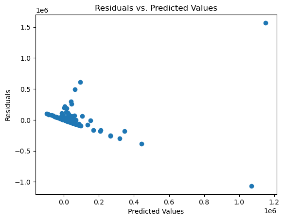

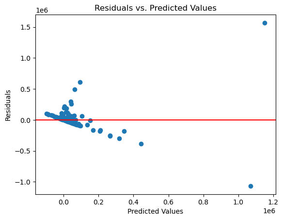

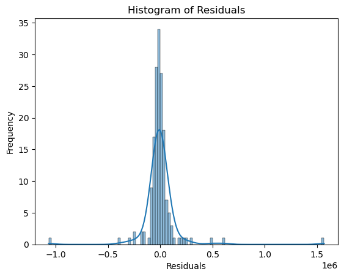

```
Durbin-Watson Statistic: 1.982986745408299
```

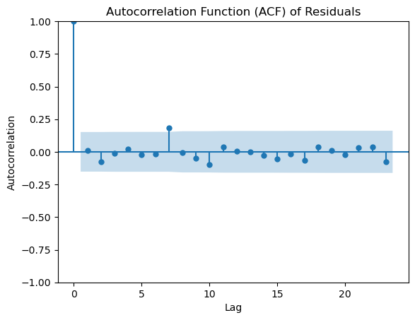

```python
import numpy as np
import statsmodels.api as sm
import statsmodels.stats.stattools as st
import matplotlib.pyplot as plt
import seaborn as sns

# Calculate Residuals
predicted_values = results.predict()
residuals = immigration['Flow'] - predicted_values

# Check for Linearity
plt.scatter(predicted_values, residuals)
plt.xlabel('Predicted Values')
plt.ylabel('Residuals')
plt.title('Residuals vs. Predicted Values')
plt.show()

# Check for Homoscedasticity
plt.scatter(predicted_values, residuals)
plt.xlabel('Predicted Values')
plt.ylabel('Residuals')
plt.title('Residuals vs. Predicted Values')
plt.axhline(y=0, color='r', linestyle='-')
plt.show()

# Normality of Residuals
sns.histplot(residuals, kde=True)
plt.title('Histogram of Residuals')
plt.xlabel('Residuals')
plt.ylabel('Frequency')
plt.show()

# Check for Autocorrelation
# Durbin-Watson statistic using DurbinWatson function
dw_statistic = st.durbin_watson(residuals)
print("Durbin-Watson Statistic:", dw_statistic)

# You can also plot autocorrelation function (ACF) of residuals if needed
sm.graphics.tsa.plot_acf(residuals)
plt.xlabel('Lag')
plt.ylabel('Autocorrelation')
plt.title('Autocorrelation Function (ACF) of Residuals')
plt.show()
```

## Conclusion

This project aims to investigate migration flows to the EU and the key determinants of these flows.

Initially, in the exploratory analysis, migration flows by sending and receiving countries, as well as by gender and age brackets, were analyzed. The migrants coming to EU countries were evenly split between males and females, with more than half of the arriving migrants considered to be young. Notably, Ukraine emerged as the primary sending country, with its invasion effect significantly shaping migration patterns.

Subsequently, the project's focus shifted towards constructing a statistical model to analyze the indicators which have a statistical significant effect on migration flows to EU27 countries.

For future studies, considerations such as geographical proximity and common language and culture could be operationalized and integrated into the model to enhance its predictive capacity.